# Chapter 4 — Confidence Intervals (R companion)

R/tidyverse translation of *Understanding Data by Alan Garfinkel and Yina Guo

Adrian Soto-Mota, MD, PhD, FACP.

2026-04-24

# Orientation

Chapter 4 (book pp. 153–186) defines the confidence interval by **resampling** (the bootstrap), not by formula. In this way, every step is transparent. The book contains **no Python code listings** in this chapter. In here, we translate the chapter’s “10,000 (virtual) friends” analogy (§4.2, p. 162) into a for-loop first, then show the idiomatic one-liner.

# §4.1 — The idea *(book p. 153)*

We have **one sample** `X` from some unknown population `U`. We’d love to know the true mean μ, but we only see `X̄` (the sample mean).

**Insight:** if we had 10,000 sister samples, we could see how `X̄` varies across them. We don’t. But **bootstrapping treats `X` as a stand-in for `U`** and resamples from `X` itself, with replacement.

# §4.2 — The bootstrap, written out *(book p. 160)*

## Set up the observed sample

The chapter uses a biological example; we use an analogous one.

```r
# One observed sample: 30 measurements
observed_X <- c(12.1, 10.8, 11.5,  9.9, 11.0, 10.6, 12.3, 11.7, 10.2, 11.1,
                10.9, 11.8, 10.5, 11.2, 12.0, 10.7, 11.4, 11.6,  9.8, 10.4,
                11.3, 10.0, 11.9, 12.2, 10.3,  9.7, 11.0, 10.8, 11.5, 10.9)
n <- length(observed_X)
obs_mean <- mean(observed_X)
obs_mean
```

```
## [1] 11.03667
```

## The faithful loop

```r
n_resamples <- 10000
boot_means  <- numeric(n_resamples)

for (i in seq_len(n_resamples)) {
  # "Put 10,000 virtual friends back into X" — sample with replacement
  resample_i       <- sample(observed_X, size = n, replace = TRUE)
  boot_means[i]    <- mean(resample_i)
}

# Same thing, idiomatic R (one line):
# boot_means <- replicate(n_resamples, mean(sample(observed_X, n, replace = TRUE)))
```

## Construct the 95 % confidence interval

```r
ci_95 <- quantile(boot_means, probs = c(0.025, 0.975))
ci_95
```

```
##     2.5%    97.5%
## 10.77333 11.30000
```

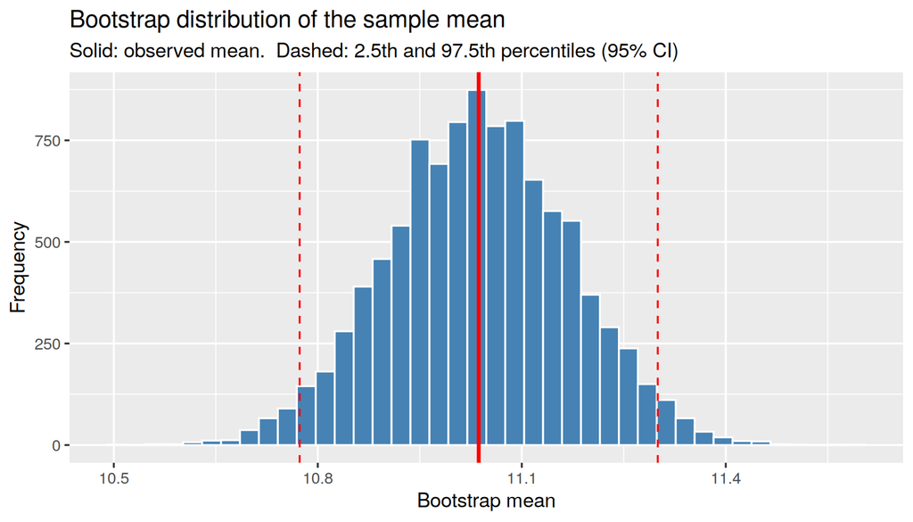

```r
tibble(boot_mean = boot_means) |>
  ggplot(aes(boot_mean)) +
  geom_histogram(bins = 40, fill = "steelblue", color = "white") +
  geom_vline(xintercept = obs_mean, color = "red", linewidth = 1) +
  geom_vline(xintercept = ci_95, color = "red",
             linetype = "dashed") +
  labs(title = "Bootstrap distribution of the sample mean",
       subtitle = "Solid: observed mean.  Dashed: 2.5th and 97.5th percentiles (95% CI)",
       x = "Bootstrap mean", y = "Frequency")
```

# §4.3 — Worked example *(book p. 168)*

Compare the bootstrap CI with the textbook t-interval:

```r
t_interval <- t.test(observed_X)$conf.int
tibble(
  method = c("Bootstrap", "t-distribution"),
  lower  = c(ci_95[1], t_interval[1]),
  upper  = c(ci_95[2], t_interval[2])
)
```

```
## # A tibble: 2 x 3
##   method         lower upper
##   <chr>          <dbl> <dbl>
## 1 Bootstrap       10.8  11.3
## 2 t-distribution  10.8  11.3
```

They agree closely because this sample is roughly Normal. For skewed or small samples they diverge — the bootstrap is more honest about the asymmetry.

# §4.4 — Bigger sample, tighter CI *(book p. 172)*

The CI width should shrink as √n.

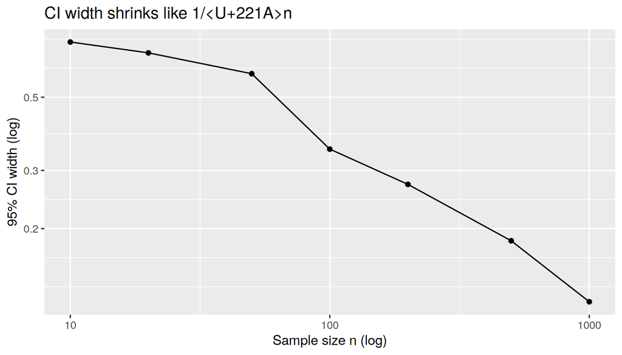

```r
# Vary n and bootstrap the CI
pop <- rnorm(100000, mean = 11, sd = 1)  # pretend this is the population

ci_width_for_n <- function(n, B = 2000) {
  samp       <- sample(pop, n)
  boot_means <- replicate(B, mean(sample(samp, n, replace = TRUE)))
  diff(quantile(boot_means, c(0.025, 0.975)))
}

widths <- tibble(
  n       = c(10, 20, 50, 100, 200, 500, 1000),
  width   = map_dbl(n, ci_width_for_n)
)

ggplot(widths, aes(n, width)) +
  geom_line() + geom_point() +
  scale_x_log10() + scale_y_log10() +
  labs(title = "CI width shrinks like 1/√n",
       x = "Sample size n (log)", y = "95% CI width (log)")
```

# §4.5 — Validating the resampling principle *(book p. 177)*

Does a 95 % CI actually contain the true mean 95 % of the time? Let’s check.

```r
true_mu <- 11                     # known population mean
n        <- 30
n_trials <- 1000                  # repeat the whole experiment 1000 times
B        <- 500                   # bootstrap replicates per trial

captured <- logical(n_trials)
for (t in seq_len(n_trials)) {
  sample_t   <- rnorm(n, mean = true_mu, sd = 1)
  boot_means <- replicate(B, mean(sample(sample_t, n, replace = TRUE)))
  ci         <- quantile(boot_means, c(0.025, 0.975))
  captured[t] <- (ci[1] <= true_mu) && (true_mu <= ci[2])
}
mean(captured)  # should be ≈ 0.95
```

```
## [1] 0.93
```

# §4.6–4.7 — Other definitions & formulas *(book p. 180)*

For the record, the textbook Normal-based formula is:

```r
X_bar <- mean(observed_X)
SE    <- sd(observed_X) / sqrt(length(observed_X))
t_critical <- qt(0.975, df = length(observed_X) - 1)

lower <- X_bar - t_critical * SE
upper <- X_bar + t_critical * SE
c(lower = lower, upper = upper)
```

```
##    lower    upper
## 10.76079 11.31255
```

This agrees with `t.test()$conf.int`. It requires the Normality assumption; the bootstrap does not.

# §4.8–4.9 — How to present and interpret a CI *(book pp. 181–182)*

**Interpret, correctly:** “If we repeated this experiment many times, 95 % of such intervals would contain the true population mean.”

# Exercises

1. Replace `observed_X` with `rexp(30, rate = 0.1)` (exponential, heavily skewed). Compare the bootstrap CI to `t.test()$conf.int`. Which one gives an asymmetric interval? Why is that more honest?
2. Run the coverage simulation (§4.5) with `n = 5`. Is the bootstrap still ≈ 95 %? Why might it under-cover for very small samples?
3. Implement the **percentile bootstrap** (shown here) and the **basic bootstrap** `2·θ̂ − q₁₋α/₂, 2·θ̂ − q_{α/2}`. Compare.